# CHLA cell line RNAseq

This document details the analysis of sequencing data acquired for comparison of the CHLA9 and CHLA10 cell lines. I am following the protocol outlined [here](https://bioconductor.org/packages/release/bioc/vignettes/DESeq2/inst/doc/DESeq2.html), as well as another detailed [here](https://bioconductor.org/packages/release/bioc/vignettes/tximport/inst/doc/tximport.html), and [here](http://master.bioconductor.org/packages/release/workflows/vignettes/rnaseqGene/inst/doc/rnaseqGene.html).

## Setting up the environment

These are packages you will need for this notebook. For exact versions used, please refer to the session info at the bottom of this notebook.

```r
##########################################################################################
library('tidyverse')
library('RColorBrewer')
library('ggplot2')
library('tximport')
library('GenomicFeatures')
library('DESeq2')
library("AnnotationDbi")
library("org.Hs.eg.db")
```

I want to set a base directory that we can use as a link to the directory where we will do most of the work. I use two directories here because the Workspace is what is pushed to GitHub and contains scripts and plot files, but the Repository is where more of the big data is stored that does not get pushed.

```r
##########################################################################################
generalDatasets = 'C:/Users/chughes/Documents/bccrc/projectsRepository/generalDatasets'
baseWorkspace = 'C:/Users/chughes/Documents/bccrc/projectsWorkspace/sorensenLab/relatedToOthers'
baseRepository = 'C:/Users/chughes/Documents/bccrc/projectsRepository/sorensenLab/relatedToOthers'
#generalDatasets = 'C:/Users/chris/OneDrive/Documents/bccrc/projectsRepository/generalDatasets'
#baseWorkspace = 'C:/Users/chris/OneDrive/Documents/bccrc/projectsWorkspace/sorensenLab/relatedToYbx1'
#baseRepository = 'C:/Users/chris/OneDrive/Documents/bccrc/projectsRepository/sorensenLab/relatedToYbx1'
```

## Data processing

First get the sample info.

```r
##########################################################################################
samples = read_csv(paste(baseRepository, '/sequencing20210218_chlaCellLineRnaseq/chla-rna-seq_sequencing-annotation.csv', sep = '')) %>%
  dplyr::mutate(cell = factor(cell))
```

Now specify the correct files for each sample.

```r
##########################################################################################
files = file.path(baseRepository, 'sequencing20210218_chlaCellLineRnaseq', paste(samples$barcode,'_quant',sep = ''), 'quant.sf')
names(files) = samples$barcode
all(file.exists(files))
```

```
[1] TRUE
```

```r
#tx2gene <- read_csv(file.path(dir, "tx2gene.gencode.v27.csv"))
```

Now build the tx2gene table. First we need to create a txdb from our GTF.

```r
##########################################################################################
myTxdb = makeTxDbFromGFF('C:/Users/chughes/Documents/bccrc/databases/hg38/gencode_gtf/hg38.gtf.gz')
```

```
Import genomic features from the file as a GRanges object ... OK
Prepare the 'metadata' data frame ... OK
Make the TxDb object ... The "phase" metadata column contains non-NA values for features of type stop_codon. This information was ignored.OK
```

Now we can select the entries we want.

```r
##########################################################################################
k = keys(myTxdb, keytype = 'TXNAME')
tx2gene = AnnotationDbi::select(myTxdb, k, 'GENEID', 'TXNAME')
```

Import the quantification data.

```r
##########################################################################################
txi = tximport(files, type = 'salmon', tx2gene = tx2gene)
```

```
reading in files with read_tsv
1 2 3 4 5 6 7 8 9
transcripts missing from tx2gene: 21785
summarizing abundance
summarizing counts
summarizing length
```

Now we can construct the DESeq2 dataset and output a report.

```r
##########################################################################################
ddsTxi = DESeqDataSetFromTximport(txi,
                                  colData = samples,
                                  design = ~ cell)
```

```
using counts and average transcript lengths from tximport
```

```r
##
dds = DESeq(ddsTxi)
```

```
using 'avgTxLength' from assays(dds), correcting for library size
```

```r
res = results(dds, contrast = c('cell','chla9','chla10'))
ens.str = substr(rownames(res), 1, 15)
res$symbol = mapIds(org.Hs.eg.db,
                     keys=ens.str,
                     column="SYMBOL",
                     keytype="ENSEMBL",
                     multiVals="first")
resOrdered = res[order(res$pvalue),]
saveRDS(resOrdered, paste(baseRepository, '/sequencing20210218_chlaCellLineRnaseq/dataset_deseq2_chla9-chla10.rds', sep = ''))
write.csv(as.data.frame(resOrdered), file = paste(baseRepository, '/sequencing20210218_chlaCellLineRnaseq/dataset_deseq2_chla9-chla10.csv', sep = ''))

##
resLFC = lfcShrink(dds, coef = "cell_chla9_vs_chla10", type = "apeglm")
```

```
using 'apeglm' for LFC shrinkage. If used in published research, please cite:
    Zhu, A., Ibrahim, J.G., Love, M.I. (2018) Heavy-tailed prior distributions for
    sequence count data: removing the noise and preserving large differences.
    Bioinformatics. https://doi.org/10.1093/bioinformatics/bty895
```

```r
resLFC
```

```
log2 fold change (MAP): cell chla9 vs chla10
Wald test p-value: cell chla9 vs chla10
DataFrame with 34023 rows and 5 columns
                      baseMean log2FoldChange     lfcSE      pvalue        padj
                     <numeric>      <numeric> <numeric>   <numeric>   <numeric>
ENSG00000000003.14 1109.586615     -0.5361350 0.0588243 7.09858e-20 8.44727e-19
ENSG00000000005.5     0.124435      0.0742174 0.7301535 7.79443e-01          NA
ENSG00000000419.12  482.369913      0.0785191 0.0903613 3.81861e-01 5.62906e-01
ENSG00000000457.13  127.578545      0.8788077 0.2794013 6.92599e-04 2.42968e-03
ENSG00000000460.16  635.486100      0.1567230 0.1208945 1.85728e-01 3.29343e-01
...                        ...            ...       ...         ...         ...
ENSG00000285982.1      1.78834    -0.00854872  0.729135    0.959413    0.979895
ENSG00000285986.1      0.00000             NA        NA          NA          NA
ENSG00000285989.1      0.00000             NA        NA          NA          NA
ENSG00000285990.1      1.22201     0.06777225  0.713417    0.708412          NA
ENSG00000285991.1     26.14622     0.29536586  0.484579    0.425963    0.607931
```

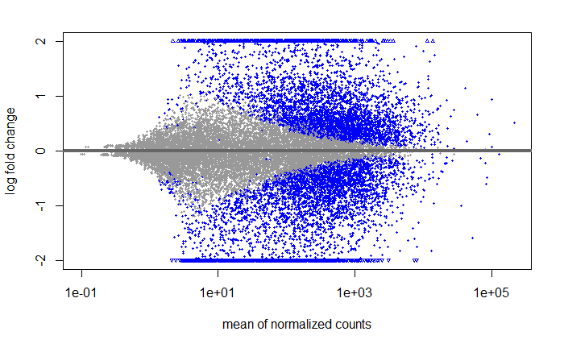

```r
plotMA(resLFC, ylim = c(-2,2))
```

[session information not shown]